[figure not shown]

Maestría · Visión Artificial · Sesión 5

# Detección de objetos: Viola-Jones y las cascadas de Haar

**Dr. Víctor Alejandro González Huitrón**  
Instituto Tecnológico de Querétaro · TecNM  
Departamento de Sistemas y Computación

01

De describir a detectar

# ¿Por qué Viola-Jones?

La sesión anterior **describía** puntos ya localizados. Hoy el problema es **encontrar** el objeto en toda la imagen, en tiempo real.

## Del descriptor a la detección

SIFT y su familia **describen y emparejan** características que ya sabemos dónde están. No responden a la pregunta previa:

¿En qué parte de la imagen —y a qué escala— hay un rostro?

Viola-Jones ataca esa pregunta: recorrer la imagen con una ventana y **clasificar** cada posición como objeto / no-objeto, con costo suficientemente bajo para video.

Viola & Jones, CVPR 2001: el primer detector de rostros práctico en **tiempo real** (~15 fps) sobre un Pentium III de 700 MHz, sin GPU.

[figure not shown]

Detección de rostro sobre una sola ventana

## La metodología y sus 3 contribuciones

Detección de objetos por **entrenamiento previo**, bajo costo computacional y buen desempeño según la curva ROC. Tres ideas la hacen posible:

- **Imagen integral:** una representación que permite calcular cualquier característica en **tiempo constante**, sin importar su tamaño.
- **AdaBoost:** aprendizaje que **selecciona** las pocas características visuales críticas y construye con ellas un clasificador fuerte.
- **Cascada:** combinar clasificadores en serie para **descartar rápido** el fondo y concentrar el cómputo en las regiones prometedoras.

El hilo conductor es la **eficiencia**: rasgos baratos, pocos rasgos, y rechazo temprano de lo que claramente no es el objeto.

## El problema: la ventana deslizante

Para detectar sin saber dónde está el objeto, se evalúa una ventana en **todas las posiciones** y se repite a **varias escalas**.

Una imagen modesta genera **cientos de miles de sub-ventanas**. Si evaluar cada una fuera caro, no habría tiempo real.

De aquí salen las 3 ideas: hacer cada evaluación **barata** (imagen integral), usar **pocas** características (AdaBoost) y **no evaluarlas todas** en la mayoría de ventanas (cascada).

02

Rasgos baratos

# Características de Haar e imagen integral

## Características tipo Haar

En vez de decidir sobre píxeles, se decide sobre **rasgos**: cada uno es la **diferencia entre la suma de píxeles** de regiones rectangulares claras y oscuras.

- **2 rectángulos** (A, B): capturan bordes.
- **3 rectángulos** (C): capturan líneas.
- **4 rectángulos** (D): capturan patrones diagonales.

Un rasgo responde alto donde la imagen se parece a su patrón. Tamaño mínimo de ventana: **24×24**; hay **>160 000** rasgos posibles en ella.

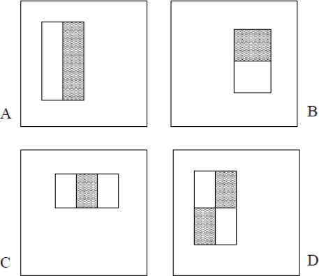

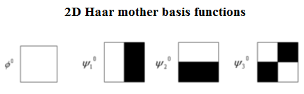

Tipos de rasgo (2, 3 y 4 rectángulos) y funciones base de Haar 2D

## La imagen integral: cómo se construye

Cada celda de **II** guarda la **suma de todo lo que está arriba y a la izquierda** (inclusive) de esa posición. Se llena en **una sola pasada**:

II(x,y) = I(x,y) + II(x−1,y) + II(x,y−1) − II(x−1,y−1)

Ejemplo, celda **(2,2)** (fila, columna desde 0): su valor en **I** más las dos celdas ya calculadas de **II** (arriba e izquierda), menos la diagonal (contada dos veces):

II(2,2) = **8** + **23** + **10** − **6** = **35**

Construir toda II cuesta **O(N)** una vez; después, cualquier consulta será **O(1)**.

Imagen I

| 1 | 2 | 8 | 9 |
| --- | --- | --- | --- |
| 2 | 1 | 9 | 8 |
| 1 | 3 | 8 | 9 |
| 2 | 2 | 9 | 8 |

→

Integral II

| 1 | 3 | 11 | 20 |
| --- | --- | --- | --- |
| 3 | 6 | 23 | 40 |
| 4 | 10 | 35 | 61 |
| 6 | 14 | 48 | 82 |

En azul, las tres celdas que alimentan la naranja (35)

## Suma de una región y gradiente en O(1)

**1) Suma de cualquier rectángulo** con 4 esquinas de II. Región 2×2 inferior derecha (celdas 8,9,9,8):

| 1 | 3 | 11 | 20 |
| --- | --- | --- | --- |
| 3 | 6<sup>A</sup> | 23 | 40<sup>B</sup> |
| 4 | 10 | 35 | 61 |
| 6 | 14<sup>C</sup> | 48 | 82<sup>D</sup> |

Suma = D − B − C + A = 82 − 40 − 14 + 6 = **34**

Igual a sumar 8+9+9+8, pero con solo **4 accesos**, sin importar el tamaño de la región.

**2) Gradiente direccional** = rasgo de 2 rectángulos: se resta la suma de dos mitades adyacentes.

| 1 | 2 | 8 | 9 |
| --- | --- | --- | --- |
| 2 | 1 | 9 | 8 |
| 1 | 3 | 8 | 9 |
| 2 | 2 | 9 | 8 |

izq = **14** · der = **68**

g = der − izq = **54**

g grande y positivo → **borde vertical** (oscuro→claro hacia la derecha). Dos rectángulos adyacentes comparten esquinas: **6–8 accesos**, independiente del tamaño → **O(1)**.

03

Aprender qué mirar

# Clasificadores débiles y Boosting (AdaBoost)

## El clasificador débil (weak learner)

El bloque mínimo: **una sola característica** con un **umbral**. Devuelve 1 o 0 según de qué lado del umbral cae la respuesta del rasgo.

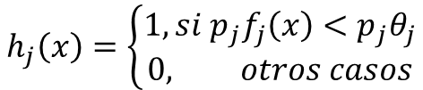

Cada débil queda definido por: característica **f**, umbral **θ** y paridad **p** (la dirección de la desigualdad). x es la ventana de 24×24.

Es **débil** a propósito: acierta apenas mejor que el azar. Error 0.1–0.3 en los rasgos principales, 0.4–0.5 en el resto. La fuerza vendrá de **combinar muchos**.

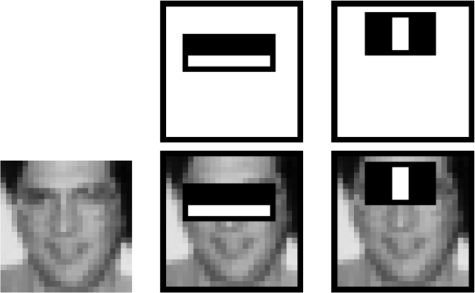

Rasgos útiles: los ojos son más oscuros que los pómulos; el puente nasal, más claro que los ojos

## ¿Qué es Boosting?

Combinar **muchos clasificadores débiles** en uno **fuerte**, entrenándolos **en secuencia**: cada nuevo débil se enfoca en los ejemplos que los anteriores fallaron.

- No se entrenan en paralelo e independientes: cada uno **corrige** al conjunto previo.
- El fuerte es un **voto ponderado**: los débiles más confiables pesan más.
- AdaBoost = "Adaptive Boosting": adapta los **pesos de los ejemplos** en cada ronda.

## AdaBoost, paso a paso

1. **Inicializar pesos** iguales sobre todos los ejemplos de entrenamiento (positivos y negativos).
2. **Elegir el mejor débil:** probar cada característica y quedarse con la de **menor error ponderado** en la ronda.
3. **Calcular su peso α:** cuanto menor su error, mayor su α (más voto en el fuerte).
4. **Re-pesar los ejemplos:** subir el peso de los **mal clasificados** para que la siguiente ronda se enfoque en ellos.
5. **Repetir** hasta juntar T débiles; el fuerte es la suma ponderada de todos.

[figure not shown]

## El clasificador fuerte y la selección de rasgos

H(x) = 1 si Σ<sub>t</sub> α<sub>t</sub> h<sub>t</sub>(x) ≥ ½ Σ<sub>t</sub> α<sub>t</sub> ; 0 en otro caso voto ponderado de T débiles: cada h<sub>t</sub> aporta según su confianza α<sub>t</sub>

Como en cada ronda AdaBoost elige **una** característica, el entrenamiento hace, de forma implícita, **selección de características**: de las >160 000 posibles, se queda con las pocas que importan.

Métodos previos usaban ~1000 rasgos; Viola-Jones logra **~95% de acierto con ~200**. En rostros, el primer rasgo elegido es casi siempre el de **ojos vs pómulos**.

¿Se parece esto a una red neuronal? Un fuerte es un **voto ponderado con umbral** = un perceptrón. Lo vemos en el siguiente slide.

## Analogía: ¿una neurona por capa?

- Cada **etapa** es un fuerte (suma ponderada de débiles + umbral) = un **perceptrón**. Un rasgo Haar suelto es una **entrada**, no la neurona.
- La **cascada** las pone **en serie**: encaja tu "una neurona por capa".
- **Diferencia clave (tu observación):** si una etapa da negativo, se **detiene**. Una MLP evalúa todas las capas siempre — ese **rechazo temprano** la abarata.
- **Sin backpropagation** ni rasgos aprendidos, y lógica **AND** entre etapas: es un **árbol de decisión degenerado**, primo de las *early-exit networks*.

[figure not shown]

04

No evaluarlo todo

# La cascada atencional

## La cascada de clasificadores

Cada etapa es un fuerte, colocado **en serie por orden de importancia**. Una ventana debe superar **todas** las etapas para declararse objeto.

Si una etapa dice "no es objeto", el proceso **termina** ahí y se pasa a la siguiente ventana. Los umbrales se ajustan para **casi no perder positivos** (pocos falsos negativos), aunque dejen pasar algunos falsos positivos a la etapa siguiente.

Se asume que hallar el objeto es un **evento raro**: la mayoría de ventanas son fondo y se descartan en las primeras 1–2 etapas, con muy pocas operaciones.

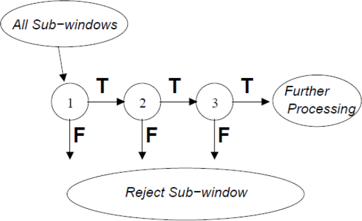

Todas las sub-ventanas entran; la mayoría se rechaza (F) temprano; solo unas pocas llegan al "further processing"

## La cascada en acción

[figure not shown]

## Optimizar la cascada

Más características → mejor detección y menos falsos positivos, pero **más tiempo**. El diseño busca el equilibrio ajustando tres perillas:

- **Número de etapas** de la cascada.
- **Número de características** por etapa.
- **Umbral** de cada etapa (compromiso entre verdaderos y falsos positivos).

Procedimiento: se fija un **mínimo de aciertos** aceptable, se empieza con una etapa sencilla y se van **agregando características/etapas** hasta alcanzar el objetivo.

El detector original de Viola-Jones llegó a **~6000 características en 38 etapas**.

## Por qué la cascada funciona: la aritmética

Con K etapas, las tasas globales son el **producto** de las tasas por etapa:

D = Π d<sub>i</sub> F = Π f<sub>i</sub> D: detección global · F: falsos positivos global · d<sub>i</sub>, f<sub>i</sub>: tasas de la etapa i

Como F es un producto de números < 1, cae **muy rápido**; D exige que cada etapa tenga d<sub>i</sub> casi 1.

**Ejemplo:** 10 etapas, cada una con d = 0.99 y f = 0.30:

D = 0.99<sup>10</sup> ≈ **0.90**

F = 0.30<sup>10</sup> ≈ **6×10⁻⁶**

Etapas **mediocres** encadenadas producen un detector con falsos positivos ínfimos y detección alta. Esa es la magia de la cascada.

05

En la práctica

# Entrenamiento del clasificador en cascada

## Los datos de entrenamiento

El detector original de rostros se entrenó con:

- **4916 positivos:** rostros recortados a mano, normalizados a ventanas de **24×24**.
- **9516 negativos:** regiones sin rostro, también a 24×24 — **más negativos que positivos**.
- Características por etapa creciendo: **1, 10, 25, 50…** hasta sumar 6061.

El dataset de un detector en cascada **no** es el de una CNN: los negativos son **imágenes de fondo sin anotación** (sin bounding box). Se detalla en la actividad.

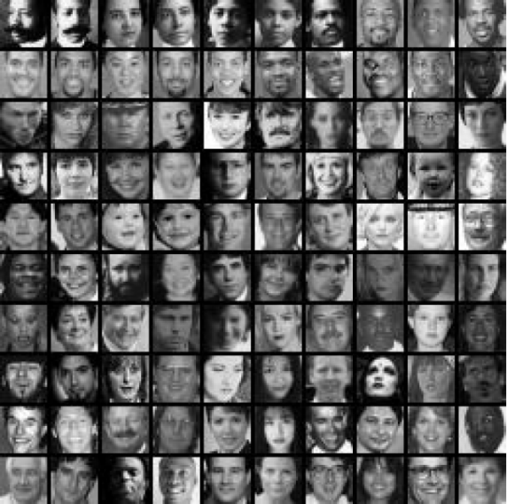

Muestras positivas normalizadas a 24×24

## Entrenar en la práctica: OpenCV y MATLAB

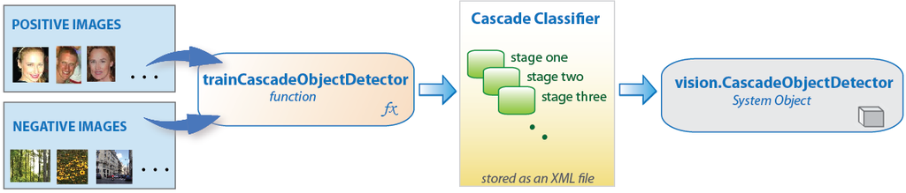

Positivos (con bbox) + negativos (imágenes de fondo, **sin** anotación) → cascada almacenada como **XML**. Mismo paradigma en OpenCV y MATLAB.

Las apps opencv_createsamples / opencv_traincascade se **removieron en OpenCV 4.x**: para entrenar hoy se usa OpenCV 3.4, MATLAB, o cascades preentrenados.

# OpenCV 3.4 — flujo típico opencv_createsamples -info pos.txt \ -vec pos.vec -w 24 -h 24 -num 4916 opencv_traincascade -data out/ \ -vec pos.vec -bg bg.txt \ -numPos 4000 -numNeg 9000 \ -numStages 20 -w 24 -h 24 \ -minHitRate 0.995 \ -maxFalseAlarmRate 0.5 \ -featureType HAAR # o LBP / HOG

Fórmula de las notas: numPos = ⌊totalPos / (1 + (numStages−1)(1−TPR))⌋

## Consideraciones y compromisos

- Más imágenes (miles) → más etapas y **menos falsos positivos**.
- Datasets pequeños → menos etapas y **más falsos positivos**.
- Subir la razón de **verdaderos positivos** reduce el riesgo de no detectar, pero un valor muy alto dispara **falsas detecciones**.
- Para reducir falsas detecciones → **aumentar el número de etapas**.

La evaluación se lee sobre la **curva ROC**: tasa de detección correcta vs. número de falsos positivos.

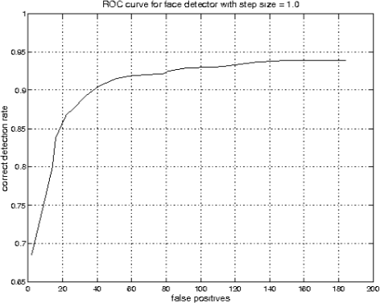

ROC del detector de rostros: la detección sube rápido y se satura ~0.93–0.94

## Resultados

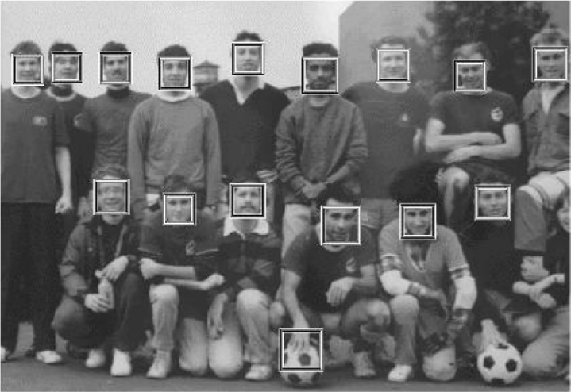

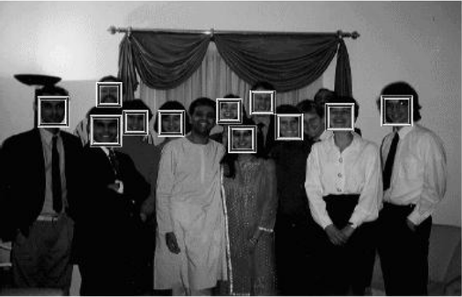

Detección robusta de múltiples rostros en tiempo real. Nótese el **falso positivo** sobre el balón (izquierda): el clasificador responde a un patrón de contraste circular parecido a un rostro — recordatorio de sus límites.

06

No todo es Haar

# Variantes: Haar vs LBP vs HOG

## ¿Qué tipos de características hay?

- **Haar** — diferencias de intensidad entre rectángulos. Detalle fino de contraste.
- **LBP** (Local Binary Patterns) — codifica la **textura** comparando cada píxel con sus vecinos → un número binario. Entero y rápido.
- **HOG** (Histogram of Oriented Gradients) — histogramas de la **orientación del gradiente**. Captura **forma/silueta**.

Haar y LBP funcionan bien con **detalles pequeños** (rostros); HOG funciona mejor con **siluetas definidas**: peatones, autos, bicicletas.

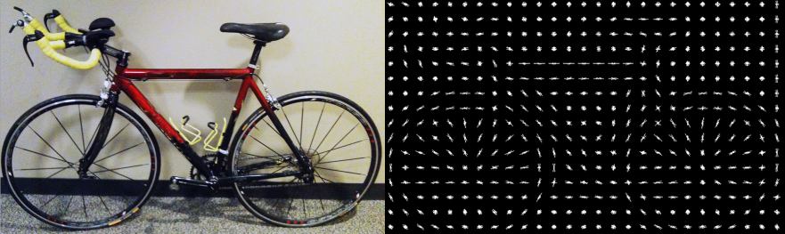

HOG: la orientación de los gradientes revela la silueta de la bicicleta

## Tabla comparativa

| Criterio | Haar | LBP | HOG |
| --- | --- | --- | --- |
| **Qué mide** | Diferencias de intensidad entre rectángulos | Patrón binario de textura del vecindario | Orientación del gradiente (forma) |
| **Tipo de dato** | Flotante (con imagen integral) | Entero | Flotante (histogramas) |
| **Entrenamiento** | Lento | Rápido | Medio |
| **Inferencia** | Baja con imagen integral | Muy baja (enteros, sin flotantes) | Media–alta |
| **Robustez a iluminación** | Baja–media | Alta (invariante monótona) | Media |
| **Mejor para** | Rostros, rasgos con contraste fino | Rostros/textura, embebidos rápidos | Siluetas: peatones, autos, bicis |
| **Ventaja** | Preciso en detalle fino | Rápido, compacto, robusto a luz | Captura forma global y contornos |
| **Desventaja** | Entrenamiento lento, sensible a luz | Menos preciso en detalle fino | Más pesado, menos apto a tiempo real duro |
| **Uso típico** | haarcascade de OpenCV | Cascadas LBP en embebidos | HOG+SVM de Dalal–Triggs (peatones) |

## ¿Cuál elegir y cuándo?

- **Haar**: cuando se busca **máxima precisión** en rasgos finos (rostros) y el entrenamiento offline no es problema.
- **LBP**: cuando importa la **velocidad** y el hardware es limitado (aritmética entera); entrena mucho más rápido, a costa de algo de precisión.
- **HOG**: cuando el objeto se define por su **silueta** (peatón, vehículo) más que por su textura interna.

Lecturas por proyecto:

P1 · IoT/RPi → LBP en el borde P2 · Mastografía → Haar/LBP en ROI P3 · ADAS → HOG (peatón/auto) P4 · ARM → benchmark Haar/LBP/HOG P5 · Diabetes → boosting tabular

07

2001 → hoy

# ¿Sigue siendo relevante?

## ¿Sigue vigente? Dónde se usa hoy

Superado en **precisión** por detectores CNN (YOLO, SSD, RetinaFace, MTCNN, BlazeFace/MediaPipe). Pero sigue vivo donde el cómputo es mínimo o no hay GPU:

- Detección de rostro/ojos por defecto en **OpenCV** (haarcascade_frontalface_default.xml).
- **Microcontroladores** y cámaras baratas; autofocus por rostro en cámaras digitales (2000s–2010s).
- Detección de ojos para **monitoreo de conductor** y parpadeo.
- Como **pre-filtro rápido** que propone regiones (ROI) antes de un modelo pesado.

Regla práctica: si necesitas precisión estado-del-arte → CNN. Si necesitas "suficientemente bueno" en tiempo real con casi nada de cómputo → la cascada sigue siendo una opción válida.

## Impacto en la visión artificial

Primer detector de objetos **práctico en tiempo real**. Popularizó tres ideas que siguen vivas:

- **Imagen integral** — reutilizada después en SURF y en filtros de caja.
- **Boosting para selección de características** — de miles de rasgos a los pocos que importan.
- **Cascada atencional / rechazo temprano** — ancestro conceptual de Cascade R-CNN y de las *early-exit networks*.

Fue el puente hacia los **Deformable Parts Models** (HOG), que dominaron la detección hasta la llegada del deep learning (~2013). Es el ejemplo canónico de "detección basada en aprendizaje".

## Para recordar

- **Imagen integral** → cualquier suma rectangular en 4 accesos (rasgos O(1)).
- **Rasgos Haar** → diferencias de intensidad; débiles pero baratos.
- **AdaBoost** → combina débiles en un fuerte y **selecciona** los pocos rasgos que importan.
- **Cascada** → etapas en serie con **rechazo temprano**; el fondo muere en las primeras etapas.
- **Variantes** → Haar/LBP para detalle fino; HOG para siluetas.

La eficiencia no es un detalle de implementación: es **el diseño**. Rasgos baratos + pocos rasgos + no evaluarlos todos.

## Actividad — Sesión 5 (por perfil)

Cada quien trabaja su perfil de proyecto. **No se implementa desde cero:** se usa OpenCV (cascades preentrenados o, si aplica, entrenamiento propio con datos proporcionados).

P1 · IoT/RPi: Haar vs LBP en el borde P2 · Mastografía: cascada como ROI + límites P3 · ADAS: peatón/auto con HOG/cascada P4 · ARM: benchmark de detectores vs YOLO P5 · Diabetes: boosting + cascada tabular

Se entrega en documento aparte, con URLs de datasets, guía de entrenamiento (positivos con bbox + negativos de fondo sin anotar, mayor razón de negativos) y rúbrica común. Se revisa la próxima sesión.

[figure not shown]

Sesión 5 · Visión Artificial

# ¿Preguntas?

Siguiente: de la detección clásica a los detectores profundos.  
**Dr. Víctor Alejandro González Huitrón** · ITQ · TecNM

Viola-Jones · cascadas de Haar

1 / 35